# **Project Title: Twitter User Insights - A Gender Driven Analysis and Engagement Strategy**

## **Project By:**

## **Chandana Nandi**

## **Geetha Mandepudi**

## **Sai Niharika Hari**

## **1)Objective of the Proposed Research**

### The "Twitter User Gender Classification" dataset's goal is to acquire insight into the gender distribution of Twitter users by examining their profiles and tweets. This dataset provides a plethora of information about Twitter users, such as their self-identified gender, their level of confidence in that identification, their tweets, profile descriptions, and a variety of other online presence-related factors. The major purpose of this study is to accurately classify or forecast the gender of Twitter users using this data.

### A digital marketing firm or a social media platform wanting to improve their targeting tactics could be one potential stakeholder for this project. Understanding the gender demographics of their customer base allows them to build more successful and personalized marketing campaigns, adverts, and content. This data could also help them detect patterns, interests, and behaviors linked with different genders, allowing them to boost user engagement and happiness.

### Academic academics or social scientists interested in investigating online behavior and gender dynamics could be another potential stakeholder. This dataset allows you to examine patterns in the type and frequency of tweets, profile descriptions, and user interactions across genders. Such research could provide useful insights on society views and habits in the digital age.

### In essence, the fundamental goal of this research is to identify Twitter users' gender and provide significant insights into gender-related trends and behaviors on social media. This information may be of significant interest and utility to a wide range of stakeholders, including marketers, social scientists, and anybody seeking a deeper knowledge of the online world and its relationship to gender dynamics.

### **2)Data Exploration**

```python
#Importing the required library
import pandas as pd

#Reading the Dataset
Dataset = pd.read_csv('gender-classifier-DFE-791531.csv')
```

```python
#printing the top 10 rows for the Dataset
print(Dataset.head(10))
```

```
    _unit_id  _golden _unit_state  _trusted_judgments _last_judgment_at  \
0  815719226    False   finalized                   3    10/26/15 23:24
1  815719227    False   finalized                   3    10/26/15 23:30
2  815719228    False   finalized                   3    10/26/15 23:33
3  815719229    False   finalized                   3    10/26/15 23:10
4  815719230    False   finalized                   3     10/27/15 1:15
5  815719231    False   finalized                   3     10/27/15 1:47
6  815719232    False   finalized                   3     10/27/15 1:57
7  815719233    False   finalized                   3    10/26/15 23:48
8  815719234    False   finalized                   3     10/27/15 1:52
9  815719235    False   finalized                   3     10/27/15 1:49

   gender  gender:confidence profile_yn  profile_yn:confidence  \
0    male             1.0000        yes                    1.0
1    male             1.0000        yes                    1.0
```

[output cut: 70 more lines]

```python
#printing the missing values and data types in the dataset
print(Dataset.info())
```

```
<class 'pandas.core.frame.DataFrame'>
RangeIndex: 20050 entries, 0 to 20049
Data columns (total 26 columns):
 #   Column                 Non-Null Count  Dtype
---  ------                 --------------  -----
 0   _unit_id               20050 non-null  int64
 1   _golden                20050 non-null  bool
 2   _unit_state            20050 non-null  object
 3   _trusted_judgments     20050 non-null  int64
 4   _last_judgment_at      20000 non-null  object
 5   gender                 19953 non-null  object
 6   gender:confidence      20024 non-null  float64
 7   profile_yn             20050 non-null  object
 8   profile_yn:confidence  20050 non-null  float64
 9   created                20050 non-null  object
```

[output cut: 19 more lines]

```python
#Printing the numbers of Rows, Columns in the Dataset
number_rows, number_columns = Dataset.shape
print(f"Number of Rows: {number_rows}")
print(f"Number of Columns: {number_columns}")
```

```
Number of Rows: 20050
Number of Columns: 26
```

```python
#Printing the Columns names in Dataset
print(Dataset.columns)
```

```
Index(['_unit_id', '_golden', '_unit_state', '_trusted_judgments',
       '_last_judgment_at', 'gender', 'gender:confidence', 'profile_yn',
       'profile_yn:confidence', 'created', 'description', 'fav_number',
       'gender_gold', 'link_color', 'name', 'profile_yn_gold', 'profileimage',
       'retweet_count', 'sidebar_color', 'text', 'tweet_coord', 'tweet_count',
       'tweet_created', 'tweet_id', 'tweet_location', 'user_timezone'],
      dtype='object')
```

```python
#Printing the percentiles of numerical values in the Dataset
print(Dataset.describe())
```

```
           _unit_id  _trusted_judgments  gender:confidence  \
count  2.005000e+04        20050.000000       20024.000000
mean   8.157294e+08            3.615711           0.882756
std    6.000801e+03           12.331890           0.191403
min    8.157192e+08            3.000000           0.000000
25%    8.157243e+08            3.000000           0.677800
50%    8.157294e+08            3.000000           1.000000
75%    8.157345e+08            3.000000           1.000000
max    8.157580e+08          274.000000           1.000000

       profile_yn:confidence     fav_number  retweet_count   tweet_count  \
count           20050.000000   20050.000000   20050.000000  2.005000e+04
mean                0.993221    4382.201646       0.079401  3.892469e+04
std                 0.047168   12518.575919       2.649751  1.168371e+05
min                 0.627200       0.000000       0.000000  1.000000e+00
25%                 1.000000      11.000000       0.000000  2.398000e+03
50%                 1.000000     456.000000       0.000000  1.144150e+04
75%                 1.000000    3315.500000       0.000000  4.002750e+04
max                 1.000000  341621.000000     330.000000  2.680199e+06

           tweet_id
count  2.005000e+04
mean   6.590000e+17
std    0.000000e+00
min    6.590000e+17
25%    6.590000e+17
50%    6.590000e+17
75%    6.590000e+17
max    6.590000e+17
```

### **3)Data Cleaning**

```python
#Checking the missing values in Dataset
Missing_Values = Dataset.isnull().sum()
print(Missing_Values)
```

```
_unit_id                     0
_golden                      0
_unit_state                  0
_trusted_judgments           0
_last_judgment_at           50
gender                      97
gender:confidence           26
profile_yn                   0
profile_yn:confidence        0
created                      0
description               3744
fav_number                   0
gender_gold              20000
link_color                   0
name                         0
profile_yn_gold          20000
profileimage                 0
retweet_count                0
sidebar_color                0
text                         0
tweet_coord              19891
tweet_count                  0
tweet_created                0
tweet_id                     0
tweet_location            7484
user_timezone             7798
dtype: int64
```

```python
#Dropping the columns that have high missing values
Columns_Drop = ['gender_gold', 'profile_yn_gold','tweet_coord']
Dataset.drop(columns=Columns_Drop, inplace = True)

#Imputing the missing values of gender column with most common gender
Most_Common_Gender = Dataset['gender'].mode()[0]
Dataset['gender'].fillna(Most_Common_Gender, inplace = True)

#Imputing missing values of the column 'description' with "Not Available"
Dataset['description'].fillna("Not Availble", inplace =True)

#Imputing missing values of the column '_last_judgment_at' with most common date
Most_Common_Date = Dataset['_last_judgment_at'].mode()[0]
Dataset['_last_judgment_at'].fillna(Most_Common_Date, inplace=True)

#Filling the columns 'tweet_location' and 'user_timezone' with "Not Specified"
Columns_fill_placeholder = ['tweet_location', 'user_timezone']
for column in Columns_fill_placeholder:
  Dataset[column].fillna("Not Specified", inplace = True)

#Checking whether 'gender:confidence' and 'profile_yn:confidence' are within the range (0 to 1)
Dataset['gender:confidence'] = Dataset['gender:confidence'].clip(0,1)
Dataset['profile_yn:confidence'] = Dataset['profile_yn:confidence'].clip(0,1)

#Saving the cleaned data to New CSV file
Dataset.to_csv('cleaned_data.csv', index=False)

#Loading the New Clean Dataset
New_Clean_Dataset = pd.read_csv("cleaned_data.csv")
```

### **Data Quality Improvement:**

### The accuracy of gender classification is determined by the quality of the data.

### Benefit to Stakeholders: The code removes or replaces missing values in columns such as 'gender_gold,' 'profile_yn_gold,' 'tweet_coord,' 'description,' and '_last_judgment_at.' This improves data quality, lowering the risk of bias or errors in the gender classification process.

### **Handling Missing Data:**

### Mission: Missing data can have an impact on the dataset's quality and completeness.

### Stakeholder Benefit: By removing columns with high missing values and imputing missing values in the 'gender' and other columns, the code ensures that the dataset is more complete and can be used effectively for gender classification.

### **Data Consistency:**

### Mission: Consistency is essential for analysis and modeling.

### Stakeholder Advantage: The code ensures that columns such as 'gender:confidence' and 'profile_yn:confidence' are within the valid range of 0 to 1. This makes the data more consistent and suitable for modeling.

### **Default Values:**

### Mission: It is critical to handle missing values properly.

### Benefit to Stakeholders: By filling missing values in columns like 'tweet_location' and 'user_timezone' with "Not Specified," the code provides a default value that ensures no information is lost when the data is used for analysis or modeling.

### **Data Saving:**

### Mission: A clean dataset is an essential resource for further analysis and modeling.

### Benefit to Stakeholders: The code saves the cleaned data to a new CSV file ('cleaned_data.csv'), which can be used as the foundation for subsequent gender analyses

## **4)Adaptation**

```python
#Adding 2 new Columns to the Dataset
New_Clean_Dataset['length_of_text'] = New_Clean_Dataset['text'].apply(len)

New_Clean_Dataset['engagement_total'] = New_Clean_Dataset['retweet_count']+ Dataset['fav_number']

print(New_Clean_Dataset.columns)
```

```
Index(['_unit_id', '_golden', '_unit_state', '_trusted_judgments',
       '_last_judgment_at', 'gender', 'gender:confidence', 'profile_yn',
       'profile_yn:confidence', 'created', 'description', 'fav_number',
       'link_color', 'name', 'profileimage', 'retweet_count', 'sidebar_color',
       'text', 'tweet_count', 'tweet_created', 'tweet_id', 'tweet_location',
       'user_timezone', 'length_of_text', 'engagement_total'],
      dtype='object')
```

### **Column 'length_of_text'**

### Usefulness in the Study: This column computes the character length of each tweet's text. It is useful for text analysis, especially if the study involves determining the impact of tweet length on engagement, sentiment, or other factors. Longer or shorter tweets may have different effects on user engagement and interactions.

### Stakeholder Advantages: This information can help stakeholders tailor their content strategy. If shorter tweets receive more engagement, they may consider crafting more concise messages. Longer tweets, on the other hand, allow for more in-depth content. It enables stakeholders to optimize their content strategy based on audience preferences and behavior.

### **Column 'engagement_total'**

### Usefulness in the Study: This column computes total engagement by adding'retweet_count' and 'fav_number.' It offers a comprehensive view of user interactions with tweets, taking into account both retweets and favorites. Understanding total engagement can aid in determining the overall success and impact of tweets.

### Stakeholder Benefits: Total engagement is an important metric for stakeholders. It indicates how well their content resonates with the audience. They can identify popular tweets, evaluate the effectiveness of their messaging, and make informed decisions about content promotion and optimization by tracking total engagement. It is a critical KPI for social media marketing strategies.

## **5)Descriptive Static Visualization**

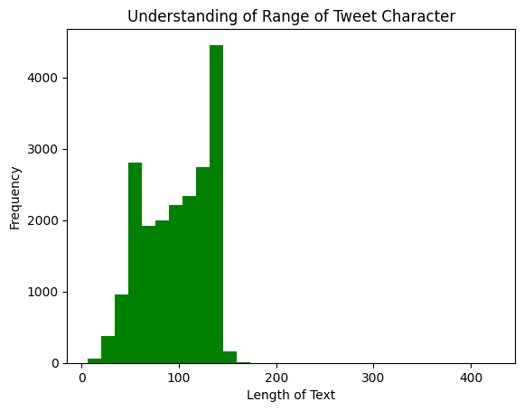

```python
import matplotlib.pyplot as plt
#ploting histogram for undersatnding the range of tweet character count
plt.hist(New_Clean_Dataset['length_of_text'], bins = 30, color = 'green')
plt.title('Understanding of Range of Tweet Character')
plt.xlabel('Length of Text')
plt.ylabel('Frequency')
plt.show()
```

### Understanding Tweet Length Distribution: The histogram shows how tweet lengths are distributed within the dataset. It displays the range of tweet character lengths, from the shortest to the longest. Stakeholders can use this information to learn about the typical or common tweet lengths in the dataset.

### Identifying Outliers: The histogram may reveal outliers or tweets with unusually long or short character lengths. Stakeholders can identify and investigate these outliers, which may be of interest for a variety of reasons, such as identifying impactful long-form tweets or spammy short tweets.

### Understanding the distribution of tweet lengths can help stakeholders involved in content strategy or social media management tailor their content creation. They can adjust their content strategy based on the typical tweet lengths that engage the audience, ensuring that their tweets align with audience preferences.

### User Engagement: The histogram can also provide information about user engagement. Stakeholders can examine whether tweets with specific character lengths receive more engagement (likes, retweets) than others. This information can be used to make decisions about tweet length in order to maximize audience engagement.

### Understanding the distribution of tweet lengths may influence how stakeholders manage social media accounts format their tweets. It can help you decide whether to keep tweets brief or use longer-form content.

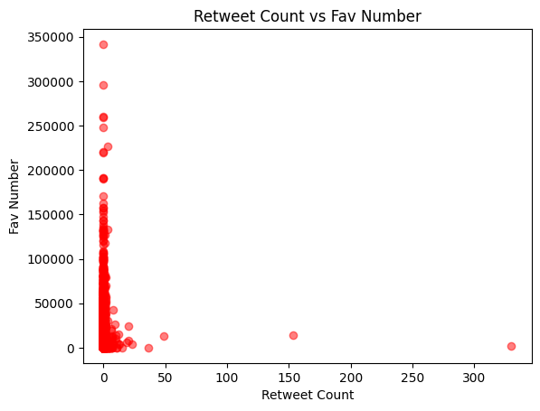

```python
#Scatter plot for showing the relation between Retweet vs Favt Count
plt.scatter(New_Clean_Dataset['retweet_count'], Dataset['fav_number'], alpha=0.5, color='red')
plt.title('Retweet Count vs Fav Number')
plt.xlabel('Retweet Count')
plt.ylabel('Fav Number')
plt.show()
```

### Understanding Engagement Patterns: The scatter plot depicts the relationship between retweets and favorites, which are both measures of user engagement. Stakeholders can learn how their audience responds to tweets. They can see if tweets that receive more favorites also receive more retweets. This information is useful for determining the effectiveness of tweet content.

### Identifying High-Impact Tweets: In the scatter plot, tweets with a high number of retweets and favorites will appear as points in the upper-right corner of the plot. These tweets have a big impact and are very engaging. Stakeholders can identify such tweets and analyze their characteristics to replicate success in future content.

### Stakeholders can use the scatter plot insights to improve their content strategy. They can experiment with different types of content, messaging, or media to see how it affects retweets and favorites. For example, knowing which types of content receive the most engagement can help guide future content creation.

### Measuring User Sentiment: The scatter plot can also assist stakeholders in determining user sentiment. Tweets with a high number of favorites often indicate that the content is well received by the audience. In contrast, a high number of retweets may indicate content that elicits strong reactions and sharing.

### Campaign Evaluation: For marketing or promotional campaigns, stakeholders can assess the success of the campaign by examining the correlation between retweets and favorites. This data can help guide future campaigns.

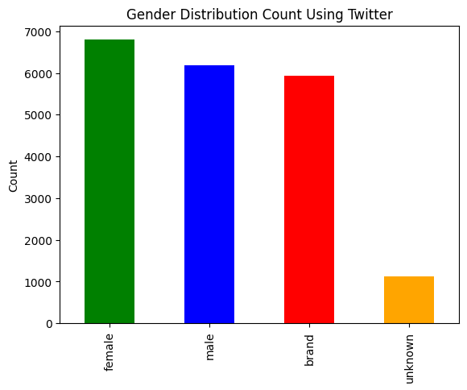

```python
#Visualization, It is a bar plot for Gender Distribution
import matplotlib.pyplot as plt
Gender_Counts = New_Clean_Dataset['gender'].value_counts()
Gender_Counts.plot(kind = 'bar', color=['green', 'blue','red','orange'])
plt.title('Gender Distribution Count Using Twitter')
plt.ylabel('Count')
plt.show()
```

### This code produces a bar chart that depicts the distribution of gender categories in the dataset. Each bar in the figure corresponds to a distinct gender category, and the height of each bar shows the number of users who fall into that category. This chart is useful to stakeholders in the following ways:

### Understanding Gender Distribution: The chart provides a clear and concise view of the gender distribution in the dataset. Stakeholders can quickly see the relative sizes of different gender categories, which may be important for targeted marketing and content strategies.

### Data-Driven Decision-Making: Stakeholders can use this information to make data-driven decisions. For example, a social media company may use this distribution to tailor its advertising and content to specific gender demographics, thereby optimizing user engagement and satisfaction.

### Identifying Imbalances: If the gender distribution is highly imbalanced, stakeholders can identify areas where they may need to focus on inclusivity or marketing efforts to target underrepresented groups.

### Comparative Analysis: The use of different colors in the bar chart allows you to quickly compare the sizes of different gender categories.

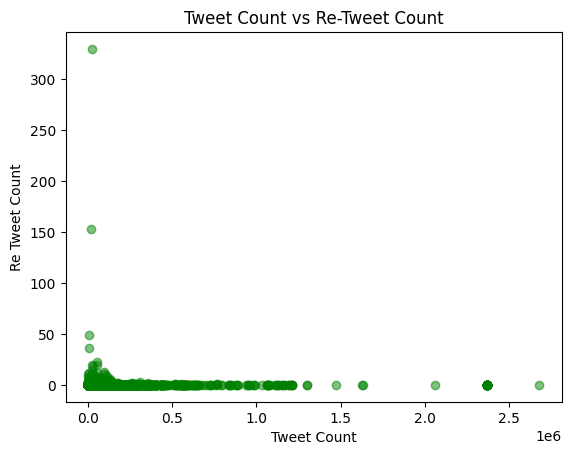

```python
#Relation between tweet count and retweet count using scatter plot
plt.scatter(New_Clean_Dataset['tweet_count'], New_Clean_Dataset['retweet_count'], alpha=0.5, color='green')
plt.title('Tweet Count vs Re-Tweet Count')
plt.xlabel('Tweet Count')
plt.ylabel('Re Tweet Count')
plt.show()
```

### Understanding Engagement Patterns: The scatter plot assists stakeholders in understanding how tweet count and retweet count are related. It reveals how frequently users tweet and how frequently their tweets are shared (re-tweeted). This understanding is critical for social media platforms, content creators, and marketers.

### Identifying Patterns and Outliers: The scatter plot can reveal patterns or outliers. Stakeholders can identify clusters of points that indicate specific behaviors. For example, they may notice a cluster of users with a high tweet count and a high re-tweet count, indicating a group of highly engaged users. They may also identify outliers—individuals with an unusually high number of retweets, who could be influencers or popular content creators.

### Assessing Engagement Strategies: Stakeholders can use this plot to evaluate the effectiveness of their engagement strategies. For example, they can determine whether there is a positive correlation between tweet count and re-tweet count, which could indicate that more active users receive more engagement. This data can be used to inform content and engagement strategies to increase user interactions.

### Understanding the relationship between tweet count and retweet count can help content creators and marketers identify content that resonates with the audience. They can concentrate on creating content that encourages retweets and engagement.

### Marketing Insights: For marketing campaigns, this plot can help stakeholders target users with specific tweet and re-tweet patterns. For example, they can create campaigns to reach out to highly active users who are more likely to purchase.

## **Cluster Analysis**

## **6)Step-by-step hierarchical Clustering:**

```python
from scipy.cluster.hierarchy import linkage, fcluster, dendrogram
import seaborn as sns

#Assigning the missing values of numerical columns with mean value of the column
DATA = New_Clean_Dataset[['_trusted_judgments', 'gender:confidence', 'profile_yn:confidence',
                 'fav_number', 'retweet_count', 'tweet_count', 'length_of_text', 'engagement_total']]

DATA = DATA.fillna(DATA.mean())

#Specifying the linkage method as ward
linkage_Method = 'ward'

#Defining the maximum number of clusters
Max_Clusters = 10

#Defining Threshold for stoping the cluster merging
threshold = 5.0

#Initializing each cluster with each of the data point as seperate cluster
Initial_Clusters = [[i] for i in range(len(DATA))]

#Performing the hierarchical clustering
results = []
for Number_Clusters in range(2, Max_Clusters +1):
  linkage_matrix = linkage(DATA, method = linkage_Method)

CLUSTERS = fcluster(linkage_matrix, t = threshold, criterion='distance')

results.append(CLUSTERS)
```

### **Exploratory Analysis with Hierarchical Clustering:**

### The mission entails categorizing Twitter users by gender.

### Benefit to Stakeholders: Hierarchical clustering is a data exploration and understanding technique. It can assist in identifying natural groupings or clusters of users based on various features. These clusters can provide insights into the diversity of Twitter users and may reveal gender patterns.

### **Identifying User Segments:**

### Mission: Effective gender classification necessitates the identification of user segments or clusters.

### Benefit to Stakeholders: Hierarchical clustering divides users into groups based on characteristics such as engagement, text length, and more. This segmentation may aid stakeholders in understanding different types of Twitter users and how they are distributed within the dataset.

### **Cluster Interpretation:**

### Mission: In order to effectively serve stakeholders, it is necessary to interpret the meaning of each cluster.

### Benefit to Stakeholders: The hierarchical clustering results provide cluster assignments. Stakeholders can examine the characteristics of users within each cluster to interpret what each cluster represents in terms of user behavior or attributes.

### **Threshold and Cluster Control:**

### The use of a threshold allows for control over the number of clusters.

### Benefit to Stakeholders: The code allows you to specify a threshold for determining the distance at which clusters should be merged. This provides control over the granularity of clustering, which can be adjusted based on the needs of stakeholders.

### **Threshold Variation and Cluster Sensitivity:**

### Mission: Hierarchical clustering can help you understand how the threshold you choose affects the number of clusters.

### Benefit to Stakeholders: The code can be run with different threshold values to see how the number of clusters varies. This sensitivity analysis can assist stakeholders in making informed decisions about the level of granularity for gender classification.

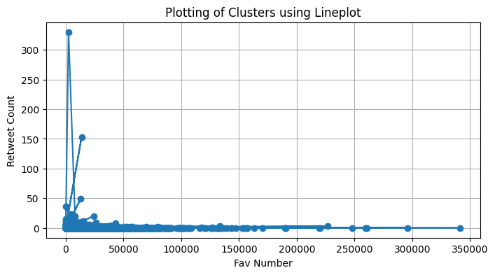

```python
#plotting the clusters using Lineplot for the columns 'fav_number' and 'retweet_count'

plt.figure(figsize=(8,4))
plt.plot(DATA['fav_number'], DATA['retweet_count'], marker= 'o', linestyle='-')
plt.title('Plotting of Clusters using Lineplot')
plt.xlabel('Fav Number')
plt.ylabel('Retweet Count')
plt.grid(True)
plt.show()
```

### **Data Exploration and Stakeholder Understanding:**

### Mission: Understanding user data is critical for making informed decisions.

### Stakeholder Benefit: The line plot provides a visual exploration of user data that can help stakeholders better understand the distribution of users and the patterns related to 'fav_number' and 'retweet_count'.

## **7)Dendrogram:**

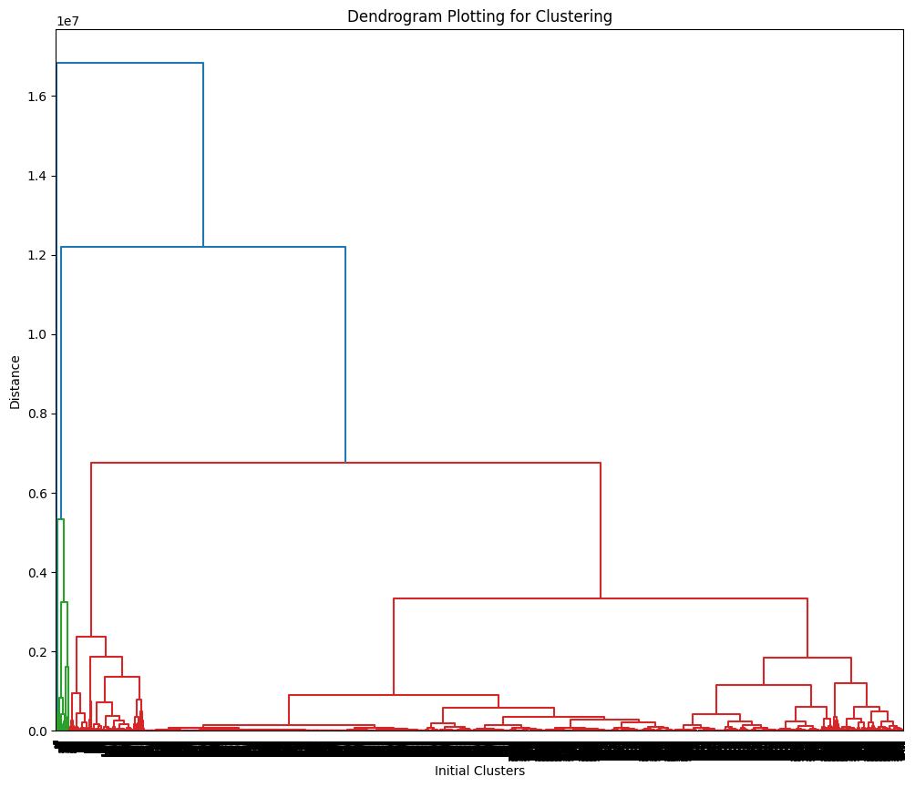

```python
#Plotting the dendrogram for one of the Clusters
plt.figure(figsize=(12,10))
dendrogram(linkage_matrix, labels=CLUSTERS)
plt.title('Dendrogram Plotting for Clustering')
plt.xlabel('Initial Clusters')
plt.ylabel('Distance')
plt.xticks()
plt.show()
```

### **Visualization of Hierarchical Cluster Structures:**

### The mission entails gender classification of Twitter users as well as understanding the natural groupings within the data.

### Benefit to Stakeholders: The dendrogram depicts how clusters form and merge in a hierarchical fashion. It assists stakeholders in understanding the relationships between clusters, from individual data points to larger merged groups. This can provide insights into the data structure as well as the possibility of gender-related patterns.

### **Cluster Hierarchy Interpretation:**

### Mission: Understanding the hierarchical structure of clusters is critical for effectively serving stakeholders.

### Benefit to Stakeholders: The dendrogram enables stakeholders to see the relationships between clusters. They can see which clusters are similar and how they are linked. This information can be used to interpret the hierarchy and make decisions.

### **Threshold Determination:**

### Mission: Hierarchical clustering allows you to limit the number of clusters by specifying a threshold distance for merging.

### Stakeholder Benefit: The dendrogram enables stakeholders to understand how the threshold selection affects the number of clusters. This can help guide decisions about the level of granularity for gender classification.

### **Data Exploration and Stakeholder Understanding:**

### Mission: Understanding user data is critical for making informed decisions.

### Stakeholder Benefit: The dendrogram serves as an exploratory tool for stakeholders to gain insights into the data's structure and diversity of user profiles. It aids in comprehending the relationships between clusters.

## **Unsupervised Clustering**

## **8)Step-by-step K-means:**

```python
import numpy as np
def kmeans(DATA, k , max_iters=100):
  np.random.seed(0)
  Cluster_Centroids = DATA.sample(n=k)

  for _ in range(max_iters):
    DATA['CLUSTERS'] = DATA.apply(lambda row: np.argmin(np.linalg.norm(row - Cluster_Centroids, axis=1)), axis=1)

    New_Cluster_Centroids = DATA.groupby('CLUSTERS').mean()

    if Cluster_Centroids.equals(New_Cluster_Centroids):
      break

      Cluster_Centroids = New_Cluster_Centroids.copy()

  return DATA['CLUSTERS']
```

### **Clustering for Exploration and Understanding:**

### The task entails categorizing Twitter users by gender. Clustering can help you analyze the distribution of user data based on numerous factors and how users are organically grouped.

### Stakeholder Benefit: By applying K-means clustering to the dataset, you can acquire insights into its structure. This might help you determine whether there are distinct groups of users who share similar traits.

### **Identifying Gender Patterns:**

### Mission: It is critical to detect patterns in data that connect with gender in order to classify users into gender categories.

### Benefit to Stakeholders: Clustering can be used as a preliminary step to find patterns in user data. For example, you might see clusters with a high number of male or female users, which can provide useful indications for constructing a gender classification model.

### **Feature Engineering:**

### Mission: Effective feature engineering is critical for gender classification. Clustering can result in the production of new features based on cluster assignments.

### Stakeholder Benefit: Features produced from clustering assignments could be employed as supplementary input for a gender categorization algorithm, thereby boosting its accuracy.

## **9)sklearn.cluster:**

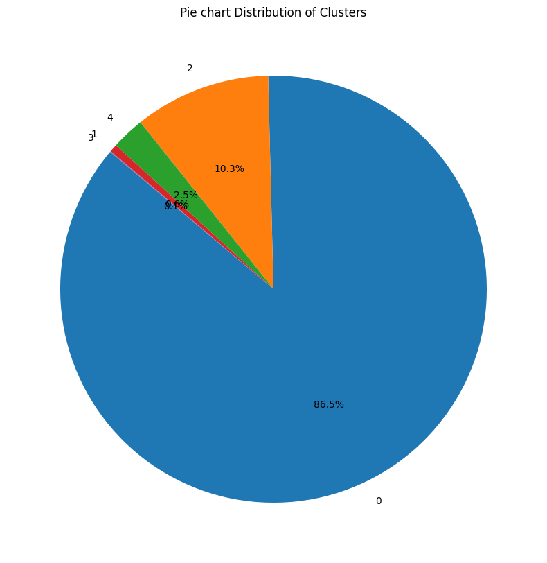

```python
DATA = DATA.fillna(DATA.mean())

from sklearn.cluster import KMeans
K= 5
Kmeans = KMeans(n_clusters=K, random_state=0, n_init=10)
Kmeans.fit(DATA[['engagement_total', 'length_of_text']])
KMeans_Result = Kmeans.labels_

Cluster_Counts = pd.Series(KMeans_Result).value_counts()

plt.figure(figsize=(10,10))
plt.pie(Cluster_Counts, labels = Cluster_Counts.index, autopct = '%1.1f%%', startangle=140)
plt.title("Pie chart Distribution of Clusters")
plt.show()
```

### **Feature Engineering and Model Input:**

### Mission: Effective feature engineering is critical for gender categorization models.

### Stakeholder Benefit: The clustering findings (cluster assignments) can be employed as extra features in gender classification models. For example, cluster assignments can aid in identifying patterns in user behavior or attributes that may be related to gender.

### **Data Exploration and Stakeholder Understanding:**

### Mission: Understanding user data is critical for making educated decisions.

### Stakeholder Benefit: Clustering and the corresponding pie chart provide stakeholders with an easy approach to study the data and acquire insights into the diversity of Twitter users. It's an excellent beginning place for talks and decision-making.

## **10)KNN Function:**

```python
from sklearn.neighbors import KNeighborsClassifier
from sklearn.preprocessing import LabelEncoder
from sklearn.preprocessing import StandardScaler


def predictKNN(k, data_point, New_Clean_Dataset):
  if 'gender' not in New_Clean_Dataset.columns:

    raise ValueError("The Dataset should contain 'gender' for classifier")

    Non_Numeric_Columns = New_Clean_Dataset.select_dtypes(exclude=[int, float]).columns
    for column in Non_Numeric_Columns:

        Label_Encoder = LabelEncoder()
        New_Clean_Dataset['gender'] = Label_Encoder.fit_transform(New_Clean_Dataset['gender'])

    Scaler = StandardScaler()
    X = Scaler.fit_transform(New_Clean_Dataset.drop('gender', axis=1))
    Y = New_Clean_Dataset['gender']

    knn = KNeighborsClassifier(n_neighbors=k)
    knn.fit(X, Y)

    Standardized_Data_Point = Scaler.transform([data_point])

    Predicted_Class = knn.predict([Standardized_Data_Point])

    Predicted_Gender = label_Encoder.inverse_transform(Predicted_Class)
    return Predicted_Gender[0]

DATASET = pd.read_csv("cleaned_data.csv")

Data_Point1 = [    1  ,  68  ,7696 ,  202, 37318,  3901,  4122  ,  80,  1825,  3115]
Data_Point2 = [110964 ,  7471  , 5617  , 1693 , 31462,  20036,  13354, 112117 ,   482 , 26085]
Data_Point3 = [1,1,1,1,1,1,1,1,1,1]
Data_Point4 = [1.0, 1.0, 1.0, 1.0, 1.0, 1.0, 1.0, 1.0 ,1.0, 1.0]
Data_Point5 = [1.0,     1.0  ,   0.6625, 1.0  ,   1.0  ,   1.0 ,    1.0   ,  1.0   ,  1.0 ,    1.0    ]
k=3


Predicted_Gender1 = predictKNN(k, Data_Point1, DATASET)
Predicted_Gender2 = predictKNN(k, Data_Point2, DATASET)
Predicted_Gender3 = predictKNN(k, Data_Point3, DATASET)
Predicted_Gender4 = predictKNN(k, Data_Point4, DATASET)
Predicted_Gender5 = predictKNN(k, Data_Point5, DATASET)
```